# FinalProject

NBA shots stats

SABRY Abdellah/ Nassim Dahmani/ Salem Ben Mabrouk

18/03/2017

# Description of the dataset

We wanted to make this project on an intersting dataset. So we’ll analyse a sport dataset. We went to kaggle.com and we found a dataset that matters us. The NBA shot logs. We downloaded the csv file. Each row is a shot of a basketball player during a match.

## Context

- 1 GAME_ID The ID of the match.
- 2 MATCHUP Date of the match separated from the two opponents.
- 3 LOCATION A : Match away, we’ll transform it in 1 H : Match at home, we’ll transform it in 0
- 4 W  
  Either the match is won by the basketball player or not. W : Won, we’ll transform it in 1 L : Lost, we’ll transform it in 0
- 5 FINAL_MARGIN Difference of points between the team of the player and the opponents.
- 6 SHOT_NUMBER ID of the shot for the player during the match.
- 7 PERIOD Number of the period.
- 8 GAME_CLOCK Time remaining before the end of the period.
- 9 SHOT_CLOCK  
  Time remaining before the shot clock.
- 10 DRIBBLES  
  Number of dribbles before the shot during this shotclock.
- 11 TOUCH_TIME The time the player keeped the ball.
- 12 SHOT_DIST The distance between the player and the basket.
- 13 PTS_TYPE The number of points corresponding of the emplacement of his shot.
- 14 SHOT_RESULT Either the shot is missed or made.
- 15 CLOSEST_DEFENDER The name of the closest defender.
- 16 CLOSEST_DEFENDER_PLAYER_ID  
  The id of the closest defender.
- 17 CLOSE_DEF_DIST The distance between the defender and the shooter.
- 18 FGM Either the shot is missed or made. 0 : Missed 1 : Made
- 19 PTS Number of the points made at the end.
- 20 player_name The name of the player.
- 21 player_id The ID of the player.

# General analysis

In a first time we clean our dataset by setting all the variables numeric

```r
dataset = read.csv("C:\\Users\\Abdel\\Desktop\\ESILV_S8\\Machine Learning\\datasets\\shot_logs.csv")
dataset=dataset[,-c(1,2,5,6,8,14,15,16,19,20,21)]
dataset$LOCATION = ifelse(dataset$LOCATION == "A", 1, 0)
dataset$W = ifelse(dataset$W == "W", 1, 0)
dataset[is.na(dataset)] <- 0
```

```r
library(caTools)
set.seed(123)

split = sample.split(dataset$FGM, SplitRatio = 0.75)
training_set = subset(dataset, split == TRUE)
test_set = subset(dataset, split == FALSE)
nrow(test_set)
```

```
## [1] 32017
```

```r
nrow(training_set)
```

```
## [1] 96052
```

```r
names <- c('LOCATION','W','PERIOD', 'SHOT_CLOCK', 'DRIBBLES','TOUCH_TIME','SHOT_DIST','CLOSE_DEF_DIST', 'PTS_TYPE')

for (name in names){
  training_set[, name] = as.numeric(training_set[,name])
  test_set[, name] = as.numeric(test_set[,name])
  dataset[,name] = as.numeric(dataset[,name])
}
dataset$FGM = as.factor(dataset$FGM)
test_set$FGM = as.factor(test_set$FGM)
training_set$FGM = as.factor(training_set$FGM)
```

You can see some graphics that describe and explain our database

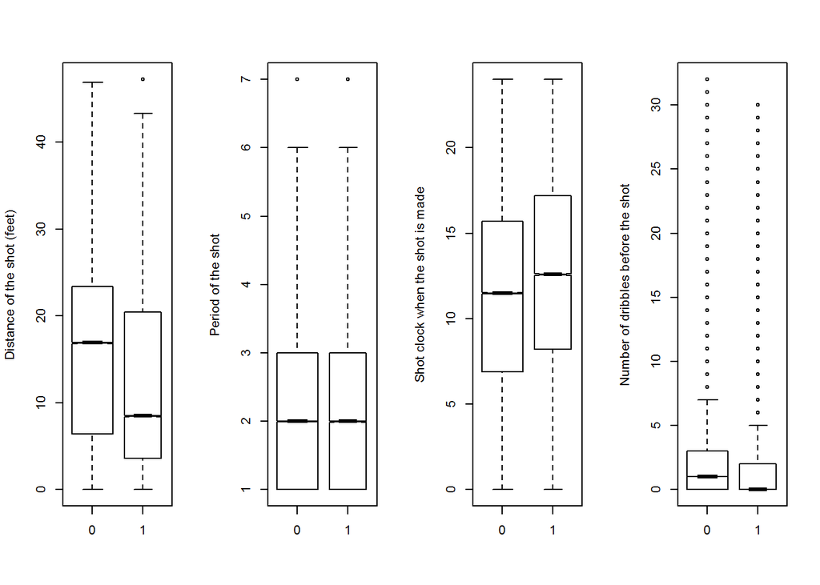

```r
par(mfrow=c(1,4))

boxplot(dataset$SHOT_DIST~ dataset$FGM,varwidth = TRUE, notch = TRUE, outline = TRUE, ylab='Distance of the shot (feet)')
boxplot(dataset$PERIOD~ dataset$FGM,varwidth = TRUE, notch = TRUE, outline = TRUE, ylab='Period of the shot')
boxplot(dataset$SHOT_CLOCK~ dataset$FGM,varwidth = TRUE, notch = TRUE, outline = TRUE, ylab='Shot clock when the shot is made')
boxplot(dataset$DRIBBLES~ dataset$FGM,varwidth = TRUE, notch = TRUE, outline = TRUE, ylab='Number of dribbles before the shot')
```

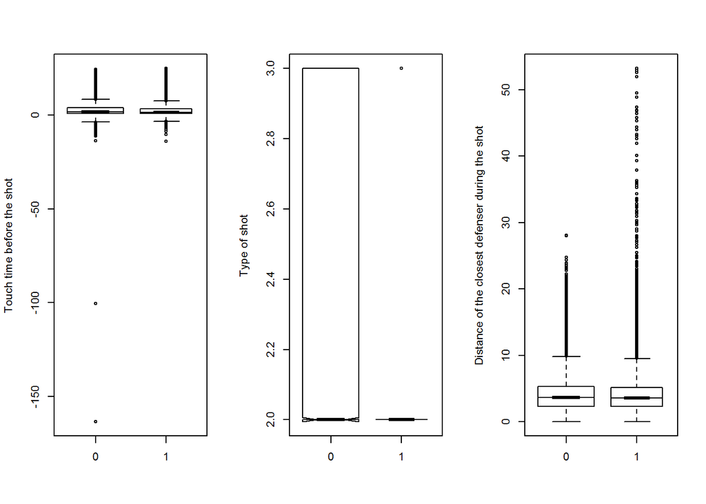

```r
par(mfrow=c(1,3))
boxplot(dataset$TOUCH_TIME~ dataset$FGM,varwidth = TRUE, notch = TRUE, outline = TRUE, ylab='Touch time before the shot')
boxplot(dataset$PTS_TYPE~ dataset$FGM,varwidth = TRUE, notch = TRUE, outline = TRUE, ylab='Type of shot')
boxplot(dataset$CLOSE_DEF_DIST~ dataset$FGM,varwidth = TRUE, notch = TRUE, outline = TRUE, ylab='Distance of the closest defenser during the shot')
```

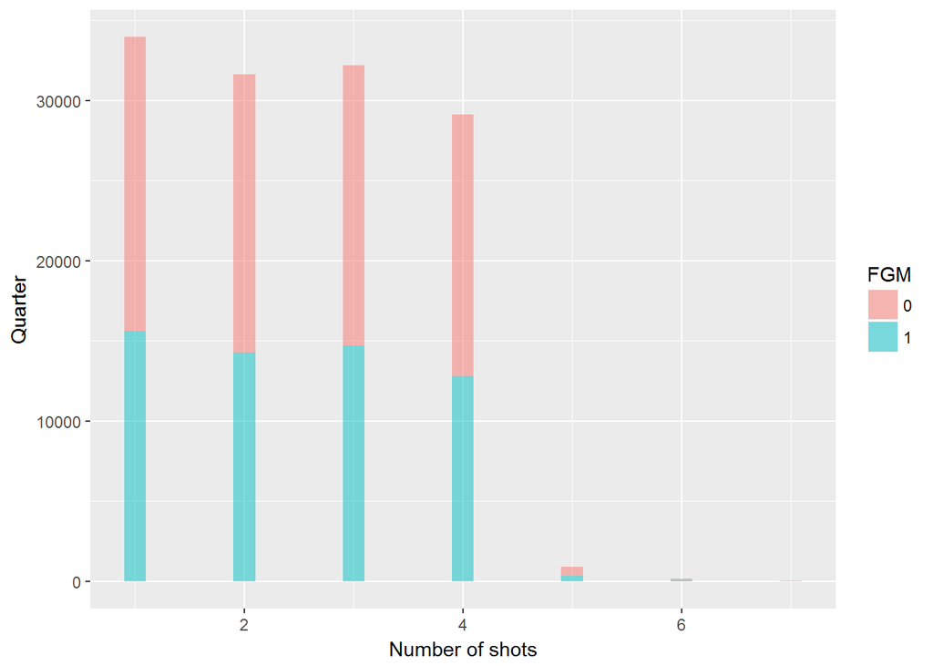

```r
library(ggplot2)
ggplot(data=dataset, aes(dataset$PERIOD, fill = FGM)) + geom_histogram(binwidth=.2, alpha=.5) + xlab("Number of shots") + ylab("Quarter")
```

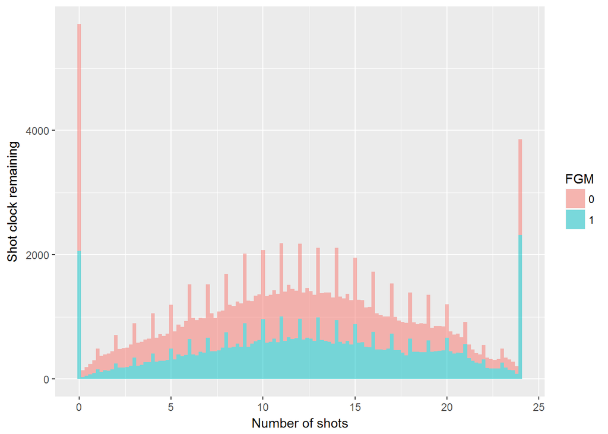

```r
ggplot(data=dataset, aes(dataset$SHOT_CLOCK, fill=FGM)) + geom_histogram(binwidth=.2, alpha=.5)+ xlab("Number of shots") + ylab("Shot clock remaining")
```

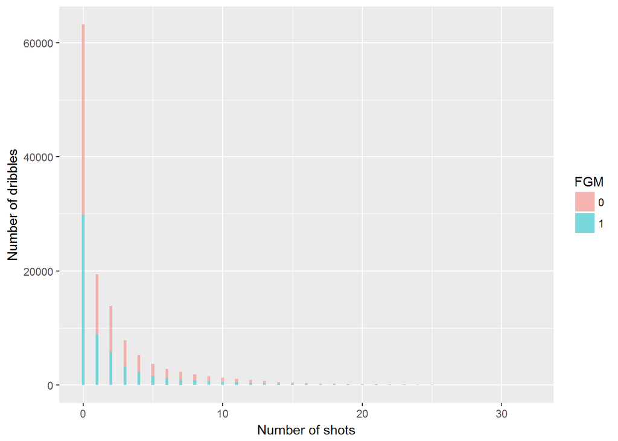

```r
ggplot(data=dataset, aes(dataset$DRIBBLES, fill=FGM)) + geom_histogram(binwidth=.2, alpha=.5) + xlab("Number of shots") + ylab("Number of dribbles")
```

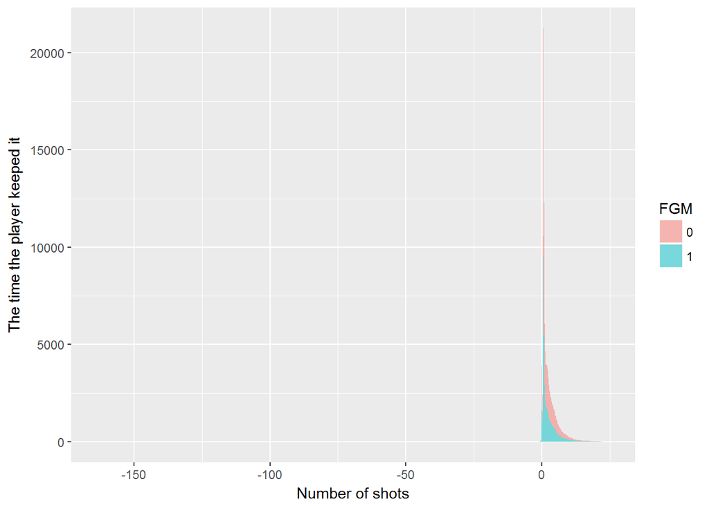

```r
ggplot(data=dataset, aes(dataset$TOUCH_TIME, fill=FGM)) + geom_histogram(binwidth=.2, alpha=.5)+ xlab("Number of shots") + ylab("The time the player keeped it")
```

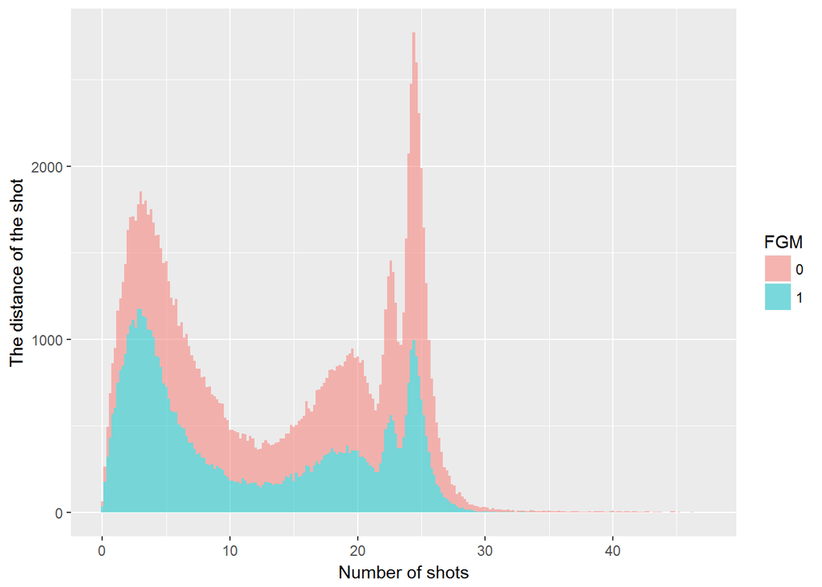

```r
ggplot(data=dataset, aes(dataset$SHOT_DIST, fill=FGM)) + geom_histogram(binwidth=.2, alpha=.5)+ xlab("Number of shots") + ylab("The distance of the shot")
```

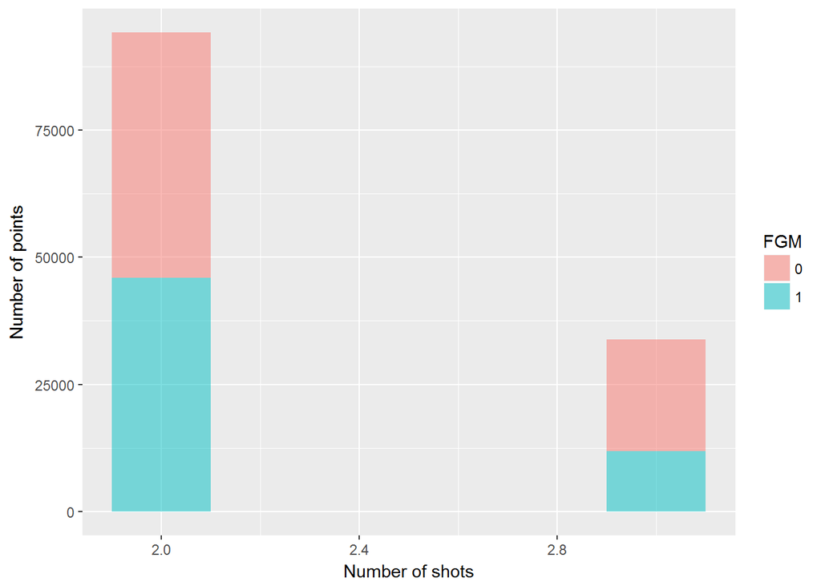

```r
ggplot(data=dataset, aes(dataset$PTS_TYPE, fill=FGM)) + geom_histogram(binwidth=.2, alpha=.5)+ xlab("Number of shots") + ylab("Number of points")
```

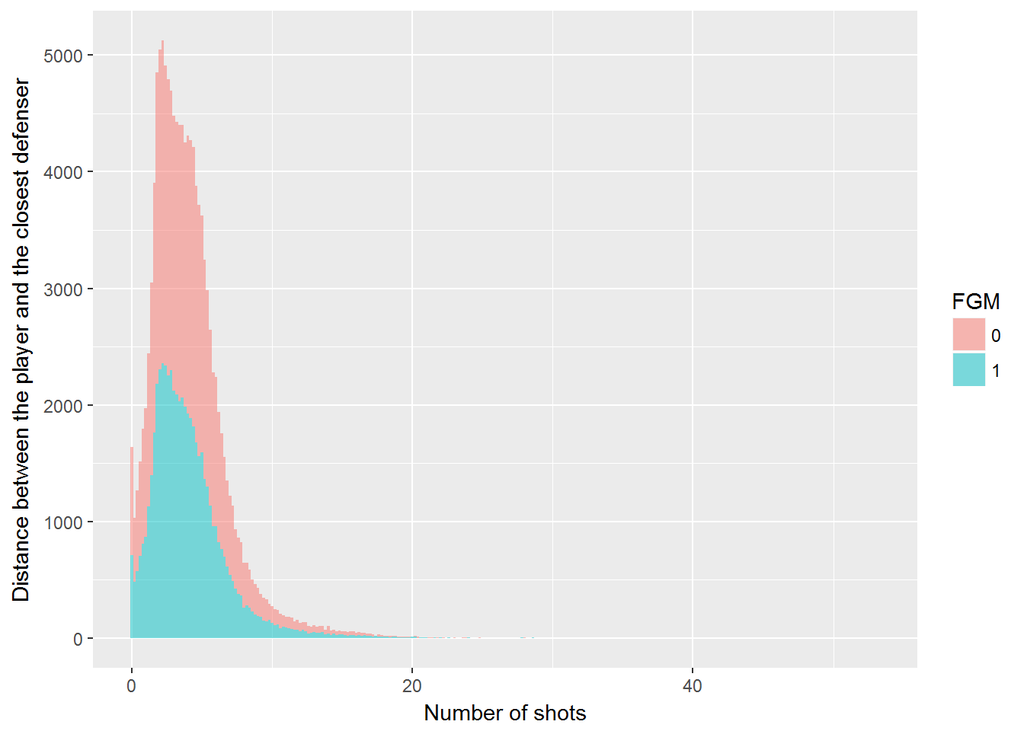

```r
ggplot(data=dataset, aes(dataset$CLOSE_DEF_DIST, fill=FGM)) + geom_histogram(binwidth=.2, alpha=.5)+ xlab("Number of shots") + ylab("Distance between the player and the closest defenser")
```

# Supervised Machine Learning

## Correlation matrix

We compute the correlation matrix to visalize the correlation between the variables.

```r
corr=training_set
corr[,"FGM"]=as.numeric(corr[,"FGM"])
correlation=round(cor(x=corr,y=corr[,"FGM"]),digits=2)
correlation
```

```
##                 [,1]
## LOCATION       -0.01
## W               0.05
## PERIOD         -0.02
## SHOT_CLOCK      0.10
## DRIBBLES       -0.03
## TOUCH_TIME     -0.05
## SHOT_DIST      -0.19
## PTS_TYPE       -0.12
## CLOSE_DEF_DIST  0.00
## FGM             1.00
```

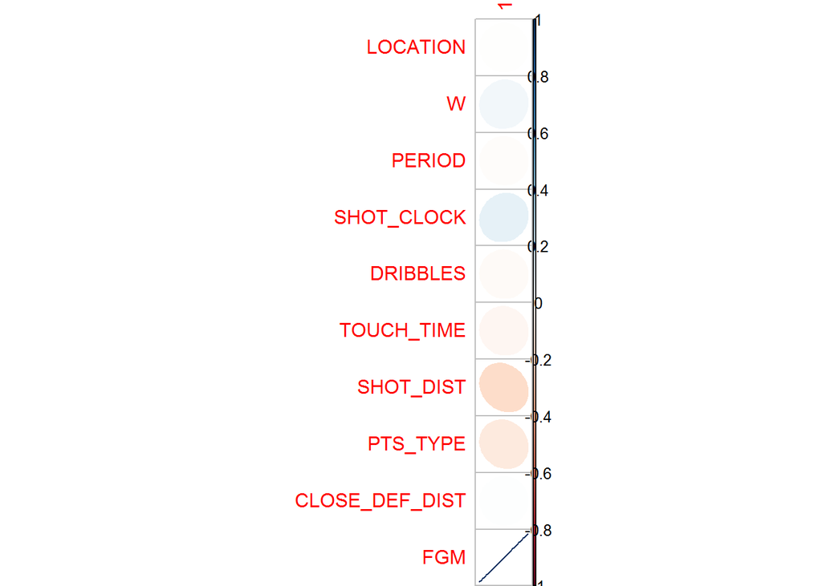

```r
library(corrplot)
corrplot(correlation,method="ellipse")
```

## Scale the variables

Then we scaled our database in order to have more precise results

```r
training_set[,-10]=scale(training_set[,-10])
test_set[,-10]=scale(test_set[,-10])
summary(training_set)
```

```
##     LOCATION             W               PERIOD          SHOT_CLOCK
##  Min.   :-0.9977   Min.   :-1.0082   Min.   :-1.2870   Min.   :-1.93037
##  1st Qu.:-0.9977   1st Qu.:-1.0082   1st Qu.:-1.2870   1st Qu.:-0.71581
##  Median :-0.9977   Median : 0.9918   Median :-0.4097   Median : 0.01294
##  Mean   : 0.0000   Mean   : 0.0000   Mean   : 0.0000   Mean   : 0.00000
##  3rd Qu.: 1.0023   3rd Qu.: 0.9918   3rd Qu.: 0.4675   3rd Qu.: 0.72548
##  Max.   : 1.0023   Max.   : 0.9918   Max.   : 3.9765   Max.   : 1.95624
##     DRIBBLES           TOUCH_TIME         SHOT_DIST
##  Min.   :-0.580752   Min.   :-54.4035   Min.   :-1.52960
##  1st Qu.:-0.580752   1st Qu.: -0.6075   1st Qu.:-1.00039
##  Median :-0.292797   Median : -0.3785   Median : 0.01299
##  Mean   : 0.000000   Mean   :  0.0000   Mean   : 0.00000
##  3rd Qu.:-0.004842   3rd Qu.:  0.3082   3rd Qu.: 1.00385
##  Max.   : 8.633817   Max.   :  7.2412   Max.   : 3.78501
##     PTS_TYPE       CLOSE_DEF_DIST    FGM
##  Min.   :-0.6003   Min.   :-1.4922   0:52623
##  1st Qu.:-0.6003   1st Qu.:-0.6603   1:43429
##  Median :-0.6003   Median :-0.1539
##  Mean   : 0.0000   Mean   : 0.0000
##  3rd Qu.: 1.6659   3rd Qu.: 0.4248
##  Max.   : 1.6659   Max.   :17.7506
```

```r
summary(test_set)
```

```
##     LOCATION             W               PERIOD          SHOT_CLOCK
##  Min.   :-1.0133   Min.   :-1.0104   Min.   :-1.2953   Min.   :-1.91621
##  1st Qu.:-1.0133   1st Qu.:-1.0104   1st Qu.:-1.2953   1st Qu.:-0.70726
##  Median : 0.9868   Median : 0.9896   Median :-0.4180   Median : 0.01811
##  Mean   : 0.0000   Mean   : 0.0000   Mean   : 0.0000   Mean   : 0.00000
##  3rd Qu.: 0.9868   3rd Qu.: 0.9896   3rd Qu.: 0.4592   3rd Qu.: 0.71124
##  Max.   : 0.9868   Max.   : 0.9896   Max.   : 3.9683   Max.   : 1.95243
##     DRIBBLES         TOUCH_TIME        SHOT_DIST            PTS_TYPE
##  Min.   :-0.5849   Min.   :-5.5957   Min.   :-1.507129   Min.   :-0.599
##  1st Qu.:-0.5849   1st Qu.:-0.6302   1st Qu.:-0.990991   1st Qu.:-0.599
##  Median :-0.2986   Median :-0.3969   Median :-0.003595   Median :-0.599
##  Mean   : 0.0000   Mean   : 0.0000   Mean   : 0.000000   Mean   : 0.000
##  3rd Qu.:-0.0123   3rd Qu.: 0.3363   3rd Qu.: 1.006241   3rd Qu.: 1.669
##  Max.   : 8.2907   Max.   : 7.2013   Max.   : 3.620594   Max.   : 1.669
##  CLOSE_DEF_DIST    FGM
##  Min.   :-1.5066   0:17541
##  1st Qu.:-0.6646   1:14476
##  Median :-0.1521
##  Mean   : 0.0000
##  3rd Qu.: 0.4336
##  Max.   :17.7490
```

## Generalized linear model (GLM)

```r
model = glm(FGM ~ CLOSE_DEF_DIST+PTS_TYPE+W,  family="binomial", data = test_set)
summary(model)
```

```
##
## Call:
## glm(formula = FGM ~ CLOSE_DEF_DIST + PTS_TYPE + W, family = "binomial",
##     data = test_set)
##
## Deviance Residuals:
##     Min       1Q   Median       3Q      Max
## -1.4746  -1.1257  -0.8733   1.2007   1.6339
##
## Coefficients:
##                Estimate Std. Error z value Pr(>|z|)
## (Intercept)    -0.19782    0.01137 -17.406   <2e-16 ***
## CLOSE_DEF_DIST  0.13764    0.01280  10.757   <2e-16 ***
## PTS_TYPE       -0.31959    0.01289 -24.794   <2e-16 ***
## W               0.09461    0.01136   8.329   <2e-16 ***
## ---
## Signif. codes:  0 '***' 0.001 '**' 0.01 '*' 0.05 '.' 0.1 ' ' 1
##
## (Dispersion parameter for binomial family taken to be 1)
##
##     Null deviance: 44091  on 32016  degrees of freedom
## Residual deviance: 43380  on 32013  degrees of freedom
## AIC: 43388
##
## Number of Fisher Scoring iterations: 4
```

```r
prediction1= predict(model,type="response",newdata = test_set)
pred1 = ifelse(prediction1 > 0.5, 1, 0)
confusMat1 = table(pred1, test_set$FGM )
confusMat1
```

```
##
## pred1     0     1
##     0 13311  9820
##     1  4230  4656
```

```r
truePos = confusMat1[2,2]
trueNeg = confusMat1[1,1]
falsePos = confusMat1[1,2]
falseNeg = confusMat1[2,1]
accuracy = (truePos+trueNeg)/(truePos+trueNeg+falseNeg+falsePos)
accuracy
```

```
## [1] 0.5611706
```

```r
sensitivity = truePos/truePos+falseNeg
sensitivity
```

```
## [1] 4231
```

```r
specificity = trueNeg/falsePos+trueNeg
specificity
```

```
## [1] 13312.36
```

But we only had an accuracy of 0.56 so i tried to erase Location and period which are unsignificant but it didn’t change anything

After observations on this graphic we had seen that the shot distance is really relevant for the shot to be missed or made

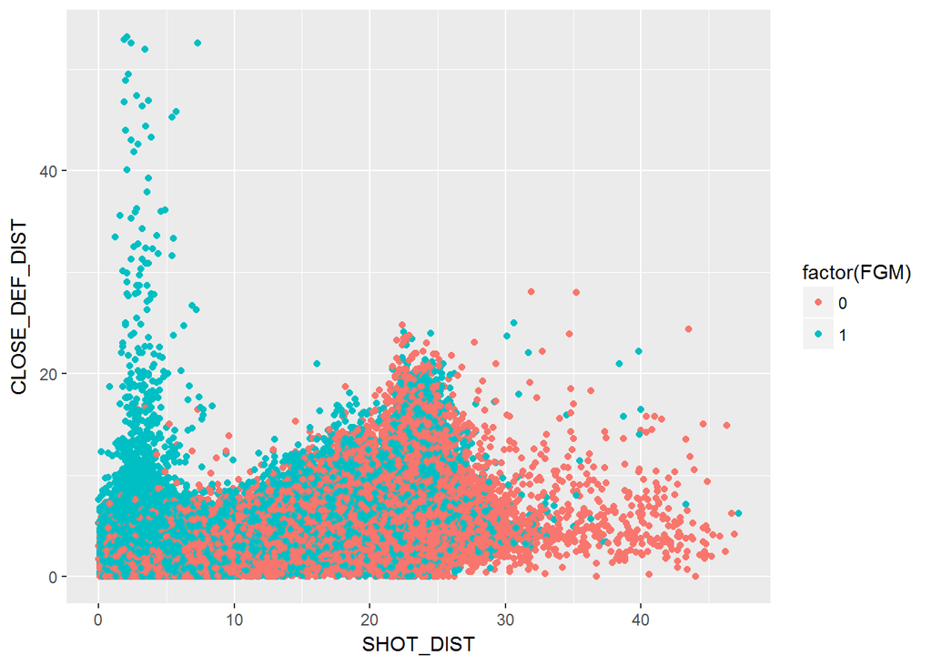

```r
ggplot(data=dataset, aes(x=SHOT_DIST, y=CLOSE_DEF_DIST)) + geom_point(aes(color=factor(FGM)))
```

So we decided to add SHOT_DIST TO our model after we plot this variables

```r
model = glm(FGM ~ CLOSE_DEF_DIST+PTS_TYPE+W+SHOT_DIST+PERIOD+LOCATION,family="binomial", data = test_set)
summary(model)
```

```
##
## Call:
## glm(formula = FGM ~ CLOSE_DEF_DIST + PTS_TYPE + W + SHOT_DIST +
##     PERIOD + LOCATION, family = "binomial", data = test_set)
##
## Deviance Residuals:
##     Min       1Q   Median       3Q      Max
## -1.9616  -1.0834  -0.8221   1.1570   1.8724
##
## Coefficients:
##                 Estimate Std. Error z value Pr(>|z|)
## (Intercept)    -0.201549   0.011552 -17.446  < 2e-16 ***
## CLOSE_DEF_DIST  0.317745   0.014895  21.332  < 2e-16 ***
## PTS_TYPE        0.046220   0.017576   2.630  0.00854 **
## W               0.090498   0.011619   7.789 6.75e-15 ***
## SHOT_DIST      -0.599347   0.019104 -31.372  < 2e-16 ***
## PERIOD          0.004928   0.011577   0.426  0.67036
## LOCATION       -0.002368   0.011614  -0.204  0.83847
## ---
## Signif. codes:  0 '***' 0.001 '**' 0.01 '*' 0.05 '.' 0.1 ' ' 1
##
## (Dispersion parameter for binomial family taken to be 1)
##
##     Null deviance: 44091  on 32016  degrees of freedom
## Residual deviance: 42346  on 32010  degrees of freedom
## AIC: 42360
##
## Number of Fisher Scoring iterations: 4
```

```r
y_prediction.logreg = predict(model,type="response",newdata = test_set)
pred1 = ifelse(y_prediction.logreg > 0.5, 1, 0)
confusMat1 = table(pred1, test_set$FGM )
truePos = confusMat1[2,2]
trueNeg = confusMat1[1,1]
falsePos = confusMat1[1,2]
falseNeg = confusMat1[2,1]
accuracy = (truePos+trueNeg)/(truePos+trueNeg+falseNeg+falsePos)
accuracy
```

```
## [1] 0.6049286
```

```r
sensitivity = truePos/truePos+falseNeg
sensitivity
```

```
## [1] 5216
```

```r
specificity = trueNeg/falsePos+trueNeg
specificity
```

```
## [1] 12327.66
```

We finished with an accuracy of 0.60 which is way much better than 0.56

Then we’ll use the MASS model with the same commands the better accuracy we had was 0.60

## Linear discriminant analysis (LDA)

```r
library(MASS)
classifier.lda <- lda(FGM ~  PTS_TYPE +SHOT_DIST + CLOSE_DEF_DIST + W+ PERIOD, data=training_set)
summary(classifier.lda)
```

```
##         Length Class  Mode
## prior    2     -none- numeric
## counts   2     -none- numeric
## means   10     -none- numeric
## scaling  5     -none- numeric
## lev      2     -none- character
## svd      1     -none- numeric
## N        1     -none- numeric
## call     3     -none- call
## terms    3     terms  call
## xlevels  0     -none- list
```

```r
y_prediction_lda=predict(classifier.lda,type="response",newdata=test_set)


confusion.lda=table(y_prediction_lda$class,test_set$FGM)
accuracy.lda=sum(diag(confusion.lda))/sum(confusion.lda)
accuracy.lda
```

```
## [1] 0.6051473
```

## Quadratic discriminant analysis (QDA)

```r
classifier.qda <- qda(FGM ~  PTS_TYPE + CLOSE_DEF_DIST+SHOT_DIST + W+ PERIOD, data=training_set)
summary(classifier.qda)
```

```
##         Length Class  Mode
## prior    2     -none- numeric
## counts   2     -none- numeric
## means   10     -none- numeric
## scaling 50     -none- numeric
## ldet     2     -none- numeric
## lev      2     -none- character
## N        1     -none- numeric
## call     3     -none- call
## terms    3     terms  call
## xlevels  0     -none- list
```

Then we had tested the qda model with the same commands the better accuracy we had was 0.60, because the Quadratic discriminant function does not assume homogeneity of variance-covariance matrices

```r
y_prediction_qda=predict(classifier.qda,type="response",newdata=test_set)


confusion.qda=table(y_prediction_qda$class,test_set$FGM)
accuracy.qda=sum(diag(confusion.qda))/sum(confusion.qda)
accuracy.qda
```

```
## [1] 0.6042415
```

In order to show the difference between the modelisation we’re gonna represent them

```r
library(ROCR)
```

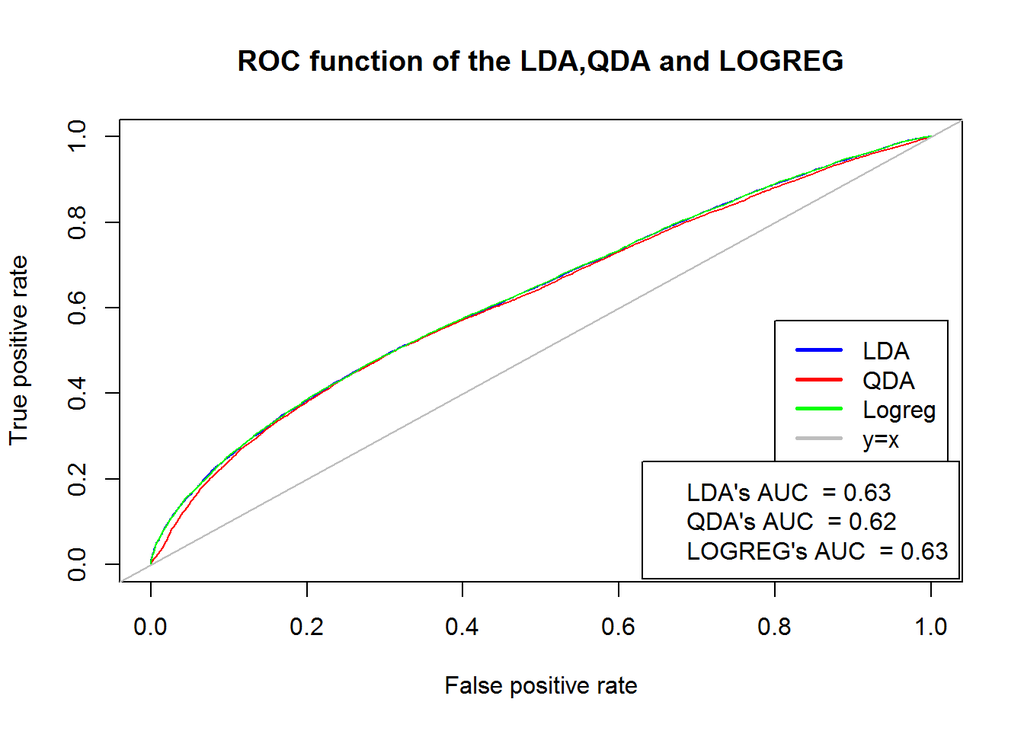

```r
performance_lda <- performance(
  prediction(y_prediction_lda$posterior[,2],test_set$FGM),
  "tpr","fpr")

plot(performance_lda,
     main="ROC function of the LDA,QDA and LOGREG",
     col="blue")

performance_qda=performance(
  prediction(y_prediction_qda$posterior[,2],test_set$FGM),
  "tpr","fpr")
plot(performance_qda,
     col="red",
     add= TRUE)

performance_logreg = performance(
    prediction(y_prediction.logreg,test_set$FGM),
    "tpr","fpr")

plot(performance_logreg,
     col="green",
     add= TRUE)

abline(a=0, b=1, col="gray")

legend(0.80,0.57,c("LDA","QDA","Logreg","y=x"),cex=1,lty=c(1,1,1,1),
       lwd=c(2.5,2.5,2.5,2.5),col=c("blue","red","green","gray"))


#to be sure we'll calculate the auc value, it's stocked in the y.Values of the result of performance (taking the parameter auc)
auc_lda= performance(prediction(y_prediction_lda$posterior[,2],test_set$FGM),"auc")
auc_lda_value = as.numeric(auc_lda@y.values)

auc_qda= performance(prediction(y_prediction_qda$posterior[,2],test_set$FGM),"auc")
auc_qda_value = as.numeric(auc_qda@y.values)

auc_logreg= performance(prediction(y_prediction.logreg,test_set$FGM),"auc")
auc_logreg_value = as.numeric(auc_logreg@y.values)

## adding the values of differents auc on the graph directly
auc_lda_tostring= paste(c("LDA's AUC  = "),round(auc_lda_value,2),sep="")
auc_qda_tostring= paste(c("QDA's AUC  = "),round(auc_qda_value,2),sep="")
auc_logreg_tostring= paste(c("LOGREG's AUC  = "),round(auc_logreg_value,2),sep="")
legend(0.63,0.24,c(auc_lda_tostring,auc_qda_tostring,auc_logreg_tostring),cex=1)
```

As we can see there are very small differencies between the three model but the more accurate we have is the lda model

# Unsupervised Machine Learning

## Principal component analysis (PCA)

```r
dataset[,"FGM"]= as.numeric(dataset[,"FGM"])
pca <- princomp(dataset, cor = TRUE)
summary(pca)
```

```
## Importance of components:
##                           Comp.1    Comp.2    Comp.3    Comp.4    Comp.5
## Standard deviation     1.5453199 1.3417426 1.0648560 1.0141497 0.9949483
## Proportion of Variance 0.2388014 0.1800273 0.1133918 0.1028500 0.0989922
## Cumulative Proportion  0.2388014 0.4188287 0.5322205 0.6350705 0.7340627
##                           Comp.6     Comp.7     Comp.8     Comp.9
## Standard deviation     0.9543354 0.92470959 0.76532818 0.47290494
## Proportion of Variance 0.0910756 0.08550878 0.05857272 0.02236391
## Cumulative Proportion  0.8251383 0.91064706 0.96921978 0.99158369
##                            Comp.10
## Standard deviation     0.290108831
## Proportion of Variance 0.008416313
## Cumulative Proportion  1.000000000
```

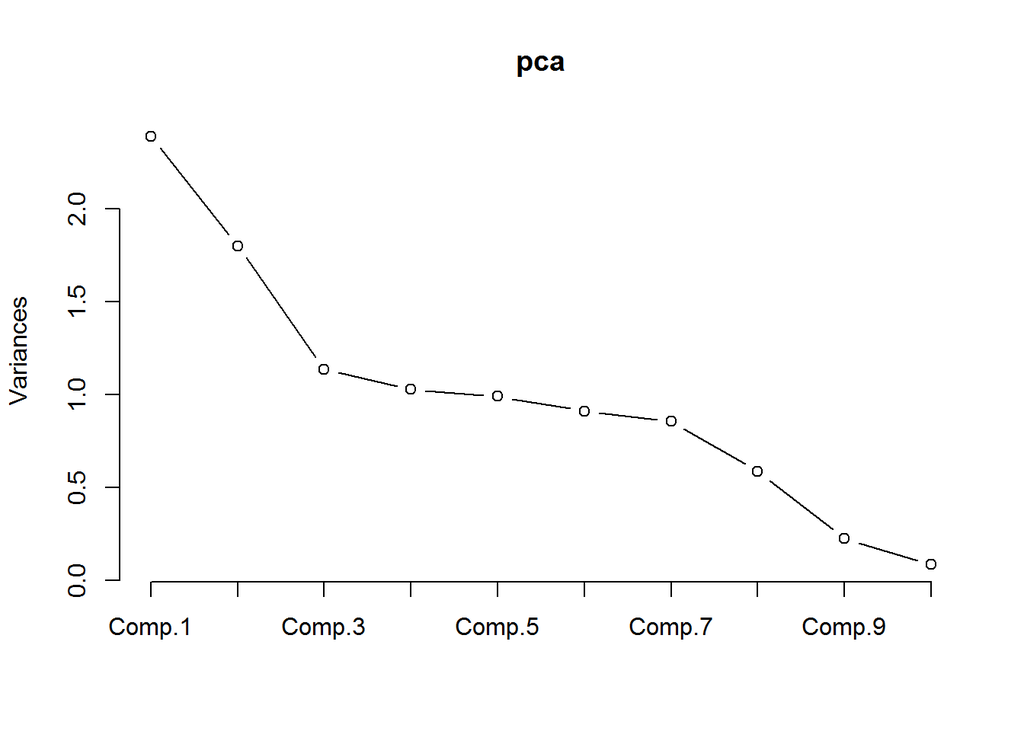

```r
plot(pca, type="l")
```

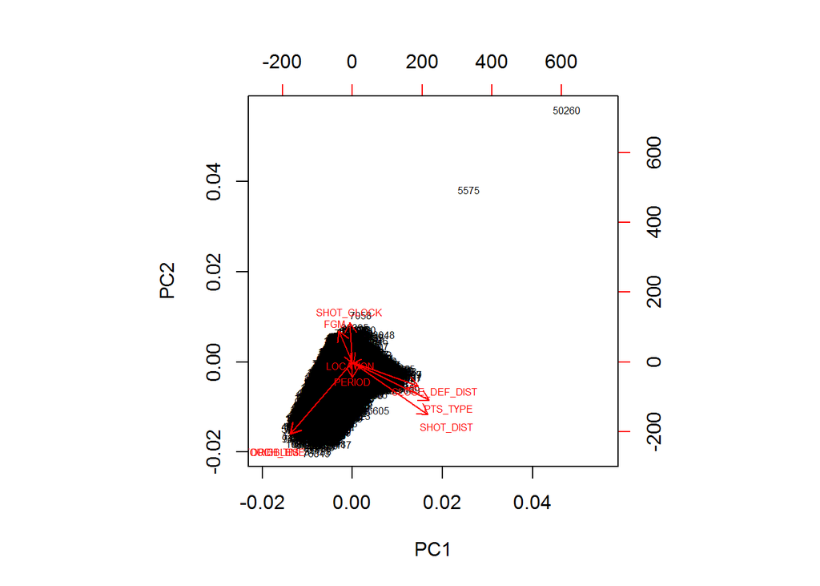

```r
biplot(pca, cex=.5,xlab="PC1" , ylab="PC2")
```

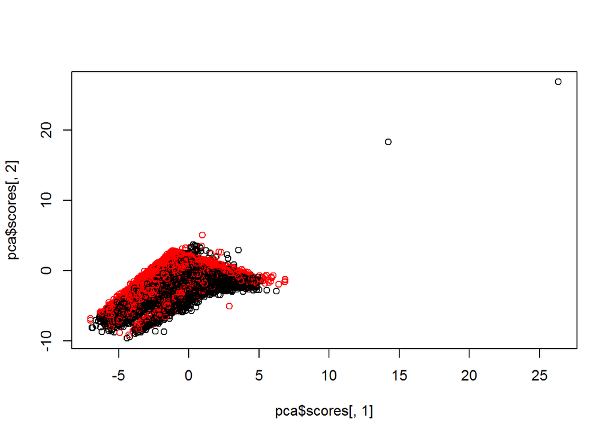

```r
plot(x=pca$scores[,1], y=pca$scores[,2],col=dataset$FGM)
```

At the beginning we thought that it would be better to split our datas in hierarchical mode, as we can’t know the number of clusters we’ll find. The dendogram cluster helps to split data in hierarchical way and so to give an idea of the correlation between observations

## Dendrogram

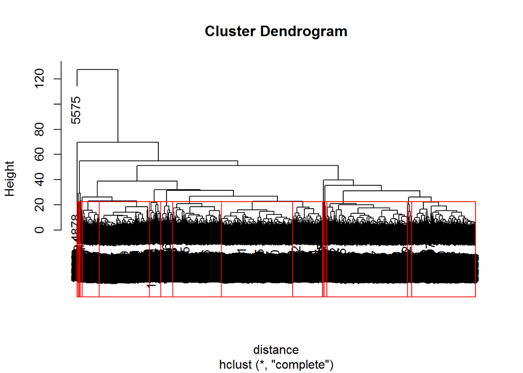

```r
dataset.first=head(dataset,10000);
distance=dist(dataset.first)
treeComp <- hclust(distance, method = "complete")
plot(treeComp)
rect.hclust(treeComp,k = 20,border="red")
```

After printing the dendogram, we’ve seen that it is impossible to create cluster like this because of the too big amount of datas

Then we decided to use the k-means to find the best clusters for the dataset. For this we used a program that permit us to choose the numbers of clusters to apply k-means. In fact, in order to apply the k-means we need to know the exact numbers of cluster

So we create a hierarchical view that permit to group variables, not observations. Clusters with AU > = 95% are considered to be strongly supported by data;

## Cluster dendrogram

```r
#install.packages("pvclust")
library(pvclust)
dataset.pv=pvclust(dataset.first);
```

```
## Bootstrap (r = 0.5)... Done.
## Bootstrap (r = 0.6)... Done.
## Bootstrap (r = 0.7)... Done.
## Bootstrap (r = 0.8)... Done.
## Bootstrap (r = 0.9)... Done.
## Bootstrap (r = 1.0)... Done.
## Bootstrap (r = 1.1)... Done.
## Bootstrap (r = 1.2)... Done.
## Bootstrap (r = 1.3)... Done.
## Bootstrap (r = 1.4)... Done.
```

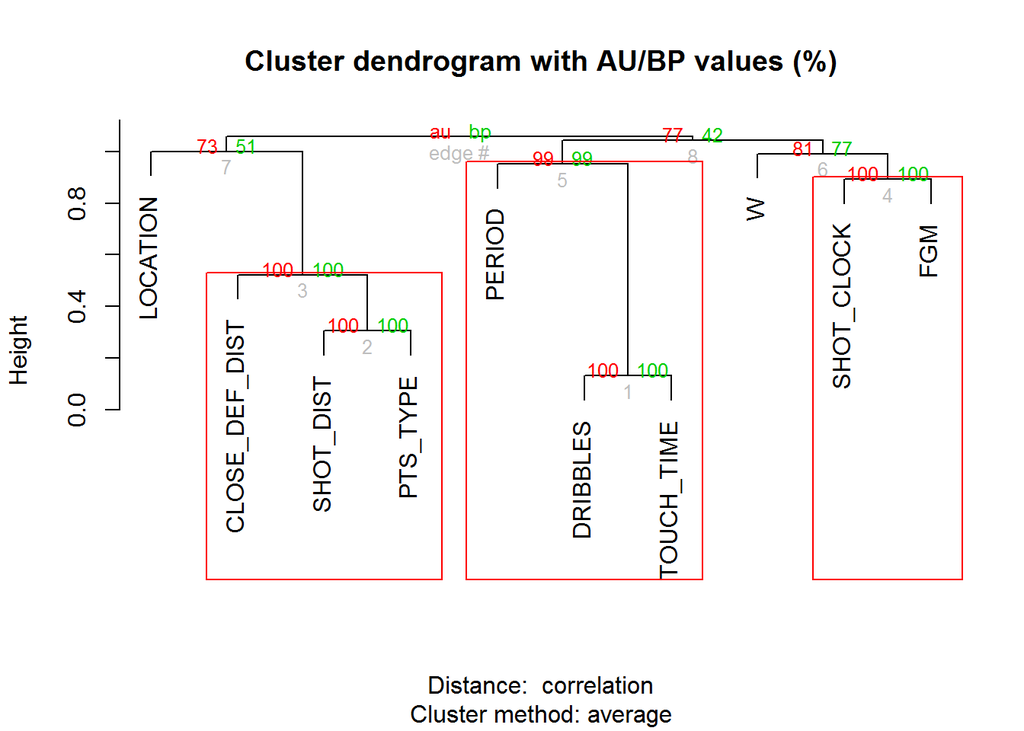

```r
plot(dataset.pv)
pvrect(dataset.pv,alpha = 0.95)
```

## K-means

```r
mydata <- dataset
within = (nrow(mydata)-1)*sum(apply(mydata,2,var))
for (i in 2:20) within[i] = sum(kmeans(mydata, centers=i)$withinss)
```

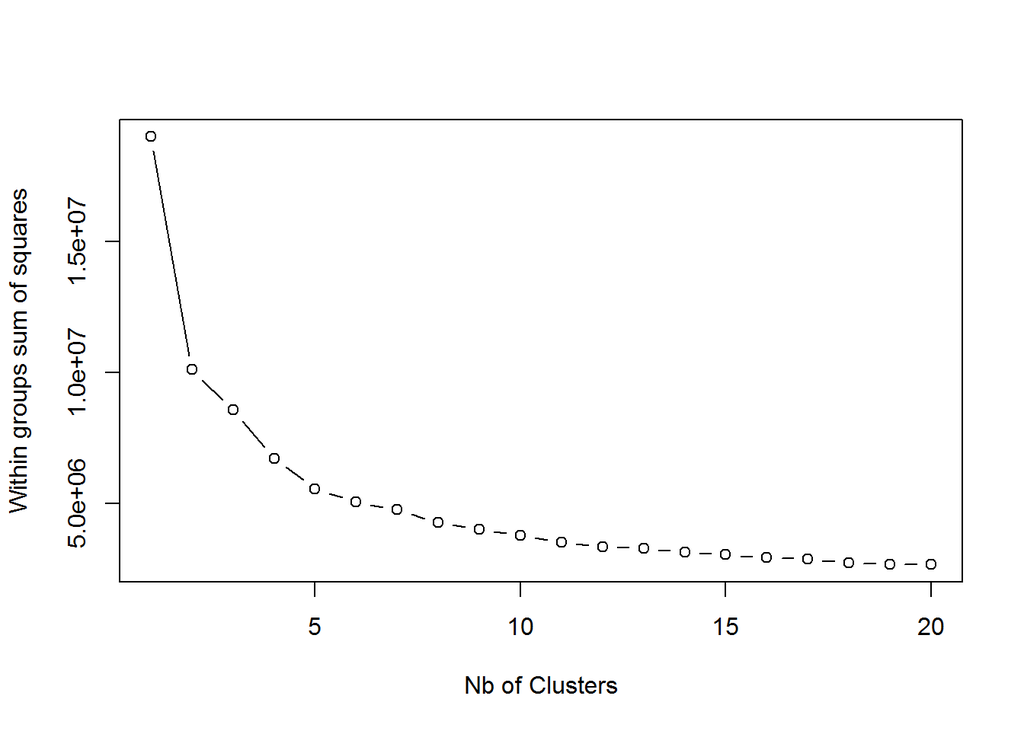

```r
plot(1:20, within, type="b", xlab="Nb of Clusters",
     ylab="Within groups sum of squares")
```

We apply the k-means on 4 cluster, we’ve seen some interesting informations as centroid place of the clusters ans the size of each cluster

```r
kmeans.dataset = kmeans(dataset,centers=4)
head(kmeans.dataset$cluster,100)
```

```
##   [1] 4 1 4 1 4 1 3 4 3 3 3 4 4 1 1 1 3 1 3 3 3 1 3 1 1 3 2 3 3 4 4 3 1 4 4
##  [36] 2 3 4 3 3 4 3 3 2 3 1 4 1 2 3 1 2 2 4 1 3 1 3 3 3 1 3 1 1 3 3 3 3 4 3
##  [71] 1 3 3 3 1 1 4 1 3 1 3 3 4 3 3 3 4 1 1 4 4 3 1 2 3 1 3 3 3 3
```

```r
# centers of each cluster
head(kmeans.dataset$centers,100)
```

```
##    LOCATION         W   PERIOD SHOT_CLOCK DRIBBLES TOUCH_TIME SHOT_DIST
## 1 0.5045281 0.5132528 2.567000   5.539685 1.817663   2.657989  21.93081
## 2 0.4943319 0.4968471 2.391207  18.697921 1.598803   2.162112   4.21794
## 3 0.4986008 0.5017284 2.427023  15.227056 1.480466   2.206768  21.63247
## 4 0.5052033 0.5062522 2.499876   8.067143 3.054628   3.879863   6.48116
##   PTS_TYPE CLOSE_DEF_DIST      FGM
## 1 2.523377       5.210709 1.351752
## 2 2.000177       2.860160 1.594197
## 3 2.538875       5.818757 1.393498
## 4 2.000883       2.585265 1.475723
```

```r
# size of each cluster
kmeans.dataset$size
```

```
## [1] 27164 28228 36450 36227
```